# R4Photobiology Start-up Guide

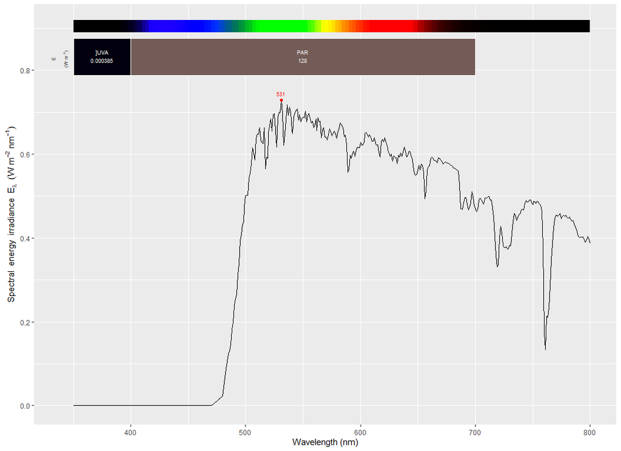

```r
autoplot(sun.spct * filters.mspct$MIDOPT_LP500)
```

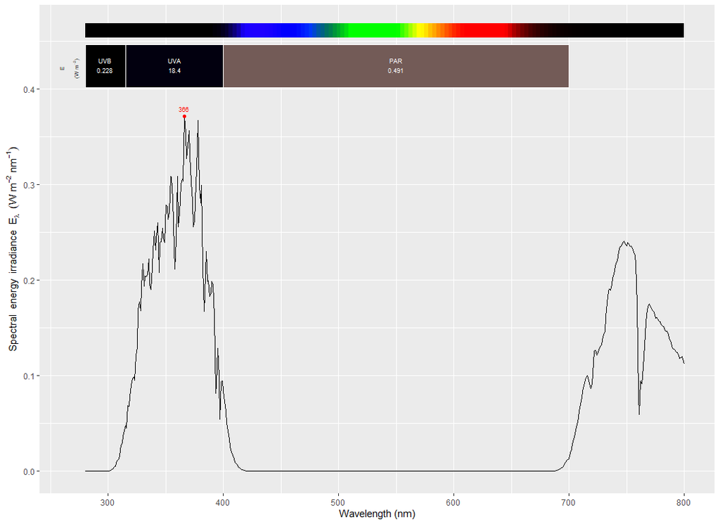

```r
autoplot(sun.spct * filters.mspct$Schott_UG1)
```

**2: Lamps**

The package **PhotobiologyLamps** contains spectral emission data for LED, fluorescent, incandescent and other lamps. Spectra for light emitting diodes (LEDs) are included in package **PhotobioloyLEDs**.

```r
names(lamps.mspct)
```

```
##  [1] "Airam.CF.15W.2700K"
##  [2] "Airam.CF.Spiraali.14W.3000K"
##  [3] "Airam.LED.11W.4000K"
##  [4] "Airam.LED.14W.4000K"
##  [5] "Airam.LED.9W.3000K"
##  [6] "Amaran.M9.LED.video.light.5500K"
##  [7] "Convoy.2plus.LED.UVA.flashlight"
##  [8] "Fluence.LED.AnthoSpec"
##  [9] "Fluence.LED.PhysioSpec.BROAD"
## [10] "Fluence.LED.PhysioSpec.BROAD.R3"
## [11] "Fluence.LED.PhysioSpec.BROAD.R6"
## [12] "Fluence.LED.PhysioSpec.BROAD.R9B"
## [13] "Fluence.LED.PhysioSpec.Greenhouse"
## [14] "Fluence.LED.PhysioSpec.Indoor"
## [15] "Generic.germicidal"
```

[output cut: 47 more lines]

```r
names(leds.mspct)
```

```
##  [1] "Agilent_HLMB_CB30"
##  [2] "Agilent_HLMB_CD31"
##  [3] "Agilent_HLMP_CB31"
##  [4] "Agilent_HLMP_CM30"
##  [5] "Agilent_HLMP_CM31"
##  [6] "Agilent_HLMP_DJ32"
##  [7] "Agilent_HLMP_DL32"
##  [8] "Bridgelux_3W_455nm"
##  [9] "Bridgelux_BXRE_50S2001_c_73"
## [10] "CREE_XPE_480nm"
## [11] "Epileds_3W_410nm"
## [12] "Epileds_3W_420nm"
## [13] "Epileds_3W_430nm"
## [14] "Epileds_3W_445nm"
## [15] "Epileds_3W_460nm"
```

[output cut: 76 more lines]

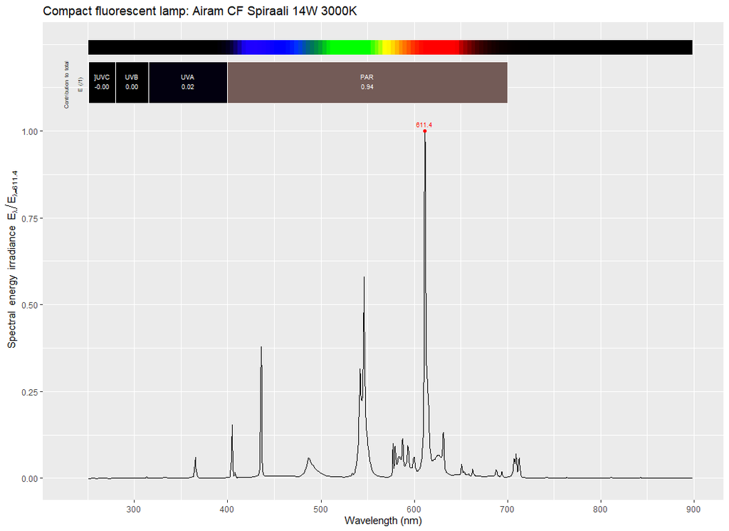

```r
autoplot(lamps.mspct$Airam.CF.Spiraali.14W.3000K, annotations = c("+", "title:what"))
```

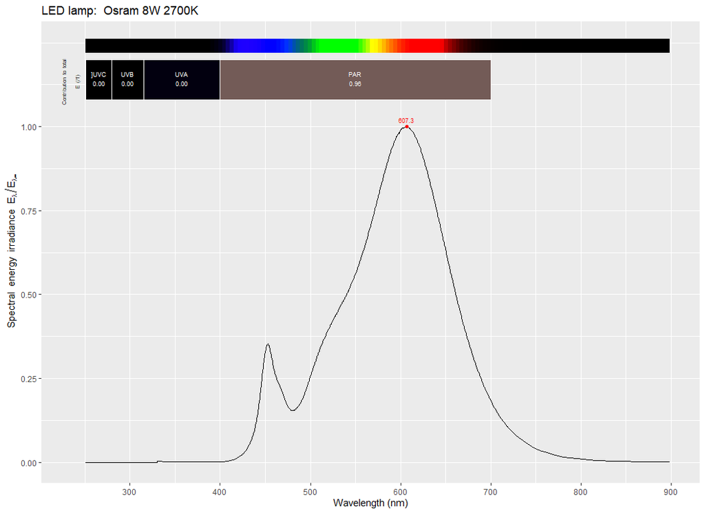

```r
autoplot(lamps.mspct$Osram.LED.8W.2700K, annotations = c("+", "title:what"))
```

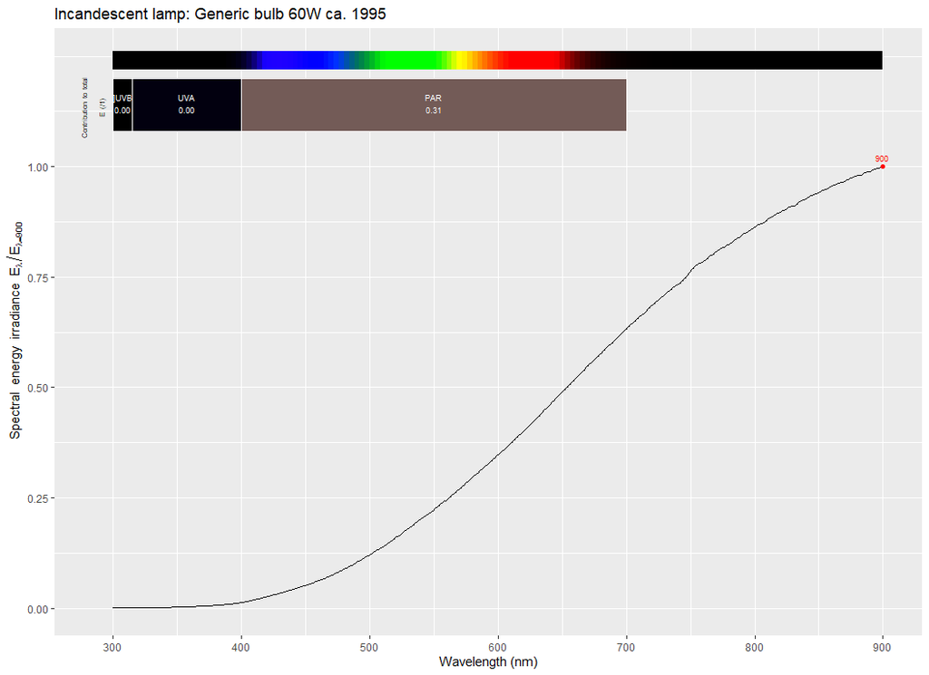

```r
autoplot(lamps.mspct$Generic.Inc.bulb.60W, annotations = c("+", "title:what"))
```

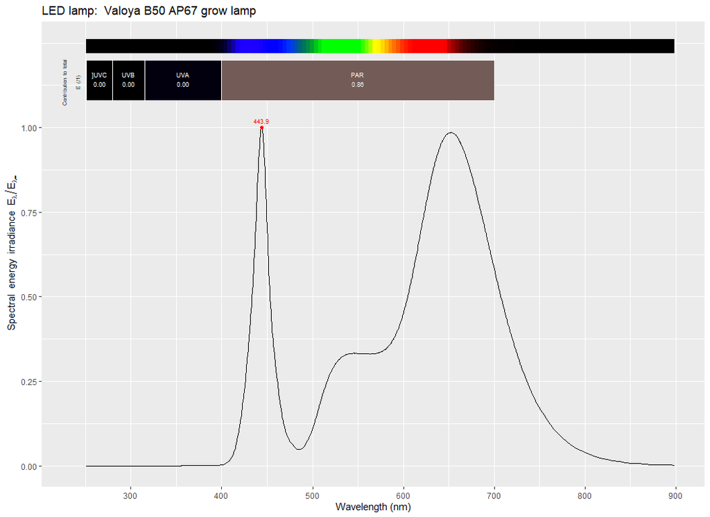

```r
autoplot(lamps.mspct$Valoya.LED.B50.AP67.LED.grow.lamp, annotations = c("+", "title:what"))
```

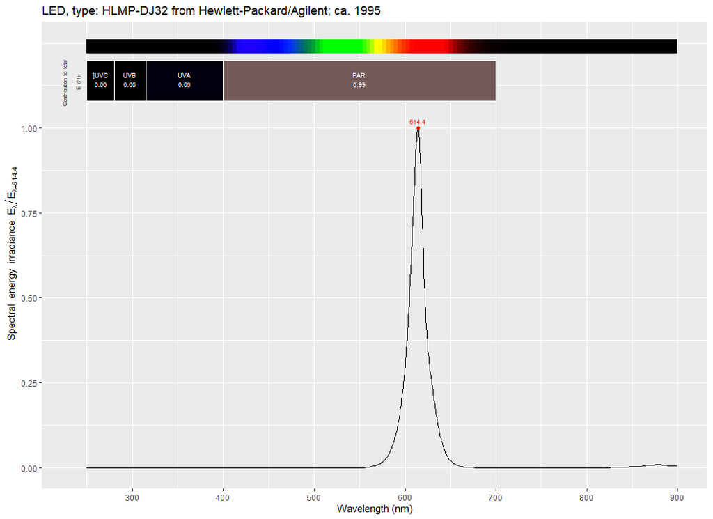

```r
autoplot(leds.mspct$Agilent_HLMP_DJ32, annotations = c("+", "title:what"))
```

# Sun calculations and astronomy

**1. Solar angles**

Solar angles are useful to know where does most of the radiation comes from. They depends on date, time, and location.

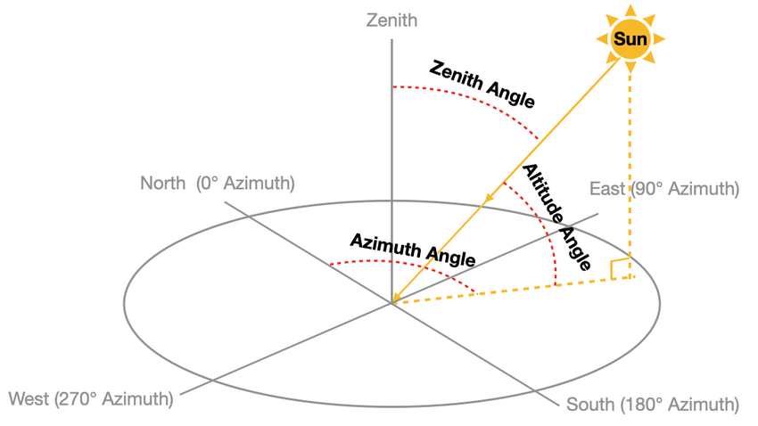

First the latitude (+ = N | - = S) and longitude (+ = E | - = W) have to be entered in decimals in a data frame. The address is a personal note (does not affect calculations).

```r
my.geocode <- data.frame(lat = 50.05, lon = 19.94, address = "Krakow")
angles <- sun_angles(time = as.POSIXct("2021-07-03 14:45:00"), geocode = my.geocode)
angles
```

```
## # A tibble: 1 × 12
##   time                tz    solartime  longitude latitude address azimuth
##   <dttm>              <chr> <solar_tm>     <dbl>    <dbl> <chr>     <dbl>
## 1 2021-07-03 14:45:00 ""    13:00:27        19.9     50.0 Krakow     209.
## # … with 5 more variables: elevation <dbl>, declination <dbl>,
## #   eq.of.time <dbl>, hour.angle <dbl>, distance <dbl>
```

```r
angles$elevation
```

```
## [1] 60.39869
```

```r
angles$azimuth
```

```
## [1] 209.0909
```

```r
angles$declination
```

```
## [1] 22.91601
```

```r
angles$hour.angle
```

```
## [1] 15.11406
```

The relative air mass can be calculated as a function of solar elevation, as an empirical *estimate* of the length of the path of the sun beam through the Earth’s atmosphere.

```r
relative_AM(c(80, 60, 40, 20))
```

```
## [1] 1.01 1.15 1.55 2.90
```

```r
relative_AM(angles$elevation)
```

```
## [1] 1.15
```

**2. Day calculations**

Calculation of solar times depends on:

- **Solar declination** (the tilt of the Earth compared to its annual orbit around the Sun).
- **Equation of time** (which depend on the eccentricity of the Earth’s orbit around the Sun).

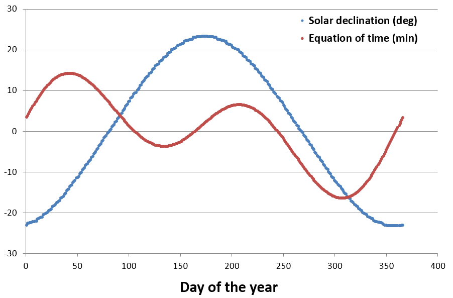

Times of solar noon, sunrise, and sunset can be easily calculated based on date and location, as well as day and night length.

```r
sunrise_time(date = as.POSIXct("2021-07-03", tz = "UTC"), geocode = my.geocode)
```

```
## [1] "2021-07-03 02:36:43 UTC"
```

```r
sunset_time(date = as.POSIXct("2021-07-03", tz = "UTC"), geocode = my.geocode)
```

```
## [1] "2021-07-03 18:52:22 UTC"
```

```r
noon_time(date = as.POSIXct("2021-07-03", tz = "UTC"), geocode = my.geocode)
```

```
## [1] "2021-07-03 10:44:32 UTC"
```

```r
day_length(date = as.POSIXct("2021-07-03", tz = "UTC"), geocode = my.geocode)
```

```
## [1] 16.26074
```

```r
night_length(date = as.POSIXct("2021-07-03", tz = "UTC"), geocode = my.geocode)
```

```
## [1] 7.739255
```

More information can be found [here.](https://docs.r4photobiology.info/photobiology/articles/userguide-2-astronomy.html)